# Usage

Two main cell magics that have been implemented in `manim_notebook` are `%%mango` and `%%manim`.

## `%%mango` cell magic

Using `%%mango` cell magic you can run manim code snippets inside that cell. Before using any of manim_notebook's cell magic you need to import `manim_notebook` first

```python
from manim_notebook import *
```

`import *` takes care of all manim imports as well. Inorder to run manim code inside any cell just begin the first line of the cell with `%%mango`. Here's a simple example.

```python
%%mango -l
circle = Circle(radius=3, stroke_width=5,
                stroke_color=YELLOW, fill_color=GREEN,
                fill_opacity=1)
self.play(ShowCreation(circle))
self.wait(4)
```

[figure not shown]

[video not shown]

Cool, isn't it? Notice that `%%mango` was supplied an additional argument `-l`. This was done inorder to render the video in low quality. `%%mango` supports all `manim` arguments. So you can use `m` for medium quality, `--high-quality` for high quality and no argument for production quality. If you want a list of all supported arguments use `%%mango -h` or `%%mango --help`. Another thing you might have noticed is that, output cell was moved to the right of input cell. This is the default behaviour but you can disable it by providing `-x` or `--no-split` as an argument to `%%mango`. The output video displayed on the browser has a frame size of 300x480(width, height) to better fit in the browser. You can change this frame size by using `-z` or `--frame-size` option. The resolution of the original video will still remain 480x854(resolution of low quality video). Remember `-z` option only changes the height and width of video being displayed on the browser and not the original video. Original video's resolution still depends on `-l`, `-m` or custom resolution passed via `-r` option.

By default you see progress bar and media in the output cell. You can use `-v` or `--verbose` option to see the complete output. Or you can use `-q` or `--quiet` option to hide progress bar as well. **CAUTION: Quiet option also suppress errors.**

But how does this code work without `construct` method and a class?  
Behind the scenes all of the code written inside the cell is wrapped inside `construct` function and a class. The default class name chosen for this purpose is `Foo` and super class is `Scene` class. After stitching everything together the code is then written inside `__temp__.py` which then will be executed by manim. You can use `--file` option to change file name from `__temp__.py` to something else.  
What if you want to create a graph? You cannot do so with `Scene` class. Fear not, you can configure super class using `%%_config` cell magic.  
If you want to use other super class like `GraphScene`, you can do so by using `%%_config -s GraphScene` and override the default values. Additionally you can also change default class name using the `-c` option. So the overall cell magic looks like this.

```python
%%_config -c PlotFunctions -s GraphScene
pass
```

`-c` option is used to set class name and `-s` option to set super class. If you can't remember everything, you can always use `-h` or `--help` option.

```python
%%_config -h
pass
```

```
usage: ipykernel_launcher.py [-h] [-s SUPER_CLASS] [-c CLASS_NAME]

Configure manim

optional arguments:
  -h, --help            show this help message and exit
  -s SUPER_CLASS, --super-class SUPER_CLASS
                        Super class name. Default super class is "Scene"
  -c CLASS_NAME, --class-name CLASS_NAME
                        Class name. Default class name is "Foo"
```

```
An exception has occurred, use %tb to see the full traceback.

SystemExit: 0
```

Instead of just using `pass` you can provide `CONFIG` dictionary and other class methods as cell body.

```python
%%_config -c PlotFunctions -s GraphScene
CONFIG = {
    "x_min" : -10,
    "x_max" : 10.3,
    "y_min" : -1.5,
    "y_max" : 1.5,
    "graph_origin" : ORIGIN ,
    "function_color" : RED ,
    "axes_color" : GREEN,
    "x_labeled_nums" :range(-10,12,2),
}
#these are class methods not ordinary functions, so you need to have
#self as the first argument
def func_to_graph(self,x):
    return x**2

def func_to_graph2(self,x):
    return -x/10
```

Now that you have configured everything, you can write your main code.

```python
%%mango -l
self.setup_axes(animate=True)
func_graph=self.get_graph(self.func_to_graph,
                          self.function_color)
func_graph2=self.get_graph(self.func_to_graph2)
vert_line = self.get_vertical_line_to_graph(TAU,
                            func_graph,color=YELLOW)

self.play(ShowCreation(func_graph),
          ShowCreation(func_graph2))
```

[figure not shown]

[video not shown]

If you want to graph functions like `sin` or `cos` you would probably import math or numpy. Simply importing them in a cell won't tell `manim_notebook` that you want to use those libraries. You will have to use `%%header` cell magic to do so.

```python
%%header
import math
```

Now you can use math functions in your manim code.

Let's put everything together.

```python
%%header
import math
```

```python
%%_config -c ExampleApproximation -s GraphScene
CONFIG = {
    "function" : lambda x : np.cos(x),
    "function_color" : BLUE,
    "taylor" : [lambda x: 1, lambda x: 1-x**2/2, lambda x: 1-x**2/math.factorial(2)+x**4/math.factorial(4),
                lambda x: 1-x**2/2+x**4/math.factorial(4)-x**6/math.factorial(6),
                lambda x: 1-x**2/math.factorial(2)+x**4/math.factorial(4)-x**6/math.factorial(6)+x**8/math.factorial(8),
                lambda x: 1-x**2/math.factorial(2)+x**4/math.factorial(4)-x**6/math.factorial(6)+x**8/math.factorial(8) - x**10/math.factorial(10)],
    "center_point" : 0,
    "approximation_color" : GREEN,
    "x_min" : -10,
    "x_max" : 10,
    "y_min" : -1,
    "y_max" : 1,
    "graph_origin" : ORIGIN ,
    "x_labeled_nums" :range(-10,12,2),

}
```

```python
%%mango -l
self.setup_axes(animate=True)
func_graph = self.get_graph(
    self.function,
    self.function_color,
)
approx_graphs = [
    self.get_graph(
        f,
        self.approximation_color
    )
    for f in self.taylor
]

term_num = [
    TexMobject("n = " + str(n),aligned_edge=TOP)
    for n in range(0,8)]
#[t.to_edge(BOTTOM,buff=SMALL_BUFF) for t in term_num]


#term = TexMobject("")
#term.to_edge(BOTTOM,buff=SMALL_BUFF)
term = VectorizedPoint(3*DOWN)

approx_graph = VectorizedPoint(
    self.input_to_graph_point(self.center_point, func_graph)
)

self.play(
    ShowCreation(func_graph),
)
for n,graph in enumerate(approx_graphs):
    self.play(
        Transform(approx_graph, graph, run_time = 2),
        Transform(term,term_num[n])
    )
    self.wait()
```

[figure not shown]

[video not shown]

That was all about `%%mango`. Now let's take a look at `%%manim` cell magic.

### `%%manim` cell magic

If you like typing your code as a whole then you can use `%%manim` cell magic. It takes complete code as it's cell body.

Let's see how to use it.

```python
%%manim -l
class Basics(Scene):
    def construct(self):
        circle = Circle(radius=3, stroke_width=5,
                        stroke_color=YELLOW,
                        fill_color=GREEN,
                        fill_opacity=1)
        self.play(ShowCreation(circle))
        self.wait(4)
```

[figure not shown]

[video not shown]

Simple, just like normal manim code. It also takes all those arguments which `%%mango` takes.

```python
%%manim -lvx -z 450,800
class MoreShapes(Scene):
    def construct(self):
        circle = Circle(color=PURPLE_A)
        square = Square(fill_color=GOLD_B, fill_opacity=1, color=GOLD_A)
        square.move_to(UP+LEFT)
        circle.surround(square)
        rectangle = Rectangle(height=2, width=3)
        ellipse=Ellipse(width=3, height=1, color=RED)
        ellipse.shift(2*DOWN+2*RIGHT)
        pointer = CurvedArrow(2*RIGHT,5*RIGHT,color=MAROON_C)
        arrow = Arrow(LEFT,UP)
        arrow.next_to(circle,DOWN+LEFT)
        rectangle.next_to(arrow,DOWN+LEFT)
        ring=Annulus(inner_radius=.5, outer_radius=1, color=BLUE)
        ring.next_to(ellipse, RIGHT)

        self.add(pointer)
        self.play(FadeIn(square))
        self.play(Rotating(square),FadeIn(circle))
        self.play(GrowArrow(arrow))
        self.play(GrowFromCenter(rectangle), GrowFromCenter(ellipse), GrowFromCenter(ring))
```

```
Media will be written to ./media/. You can change this behavior with the --media_dir flag.
```

```
File ready at /home/akash/akash/media/videos/__temp__/480p15/MoreShapes.mp4

Played 4 animations
```

[video not shown]

```python
%%manim Class1 Class2 Class3 -l
class Class1(Scene):
    def construct(self):
        square = Square()
        self.play(ShowCreation(square))
        self.wait(4)
class Class2(Scene):
    def construct(self):
        circle = Circle()
        self.play(ShowCreation(circle))
        self.wait(4)
class Class3(Scene):
    def construct(self):
        triangle = Triangle()
        self.play(ShowCreation(triangle))
        self.wait(4)
```

[figure not shown]

[video not shown]

or leaving class name altogether to choose from a list.

```python
%%manim -l
class Class1(Scene):
    def construct(self):
        square = Square()
        self.play(ShowCreation(square))
        self.wait(4)
class Class2(Scene):
    def construct(self):
        circle = Circle()
        self.play(ShowCreation(circle))
        self.wait(4)
class Class3(Scene):
    def construct(self):
        triangle = Triangle()
        self.play(ShowCreation(triangle))
        self.wait(4)
```

[figure not shown]

```
1: Class1
2: Class2
3: Class3

Choose number corresponding to desired scene/arguments.
(Use comma separated list for multiple entries)
Choice(s): 1,2
```

[video not shown]

You can also use `-s` option to view just the last frame.

[figure not shown]

```
1: Class1
2: Class2
3: Class3

Choose number corresponding to desired scene/arguments.
(Use comma separated list for multiple entries)
Choice(s): 1,2,3
```

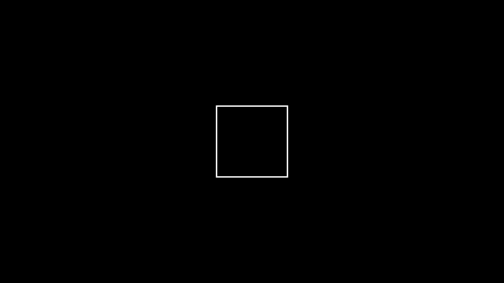

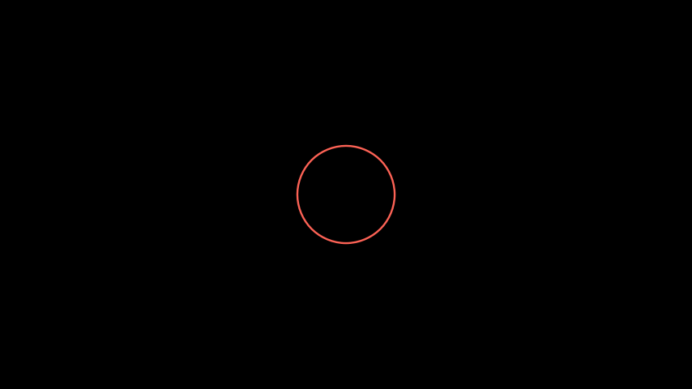

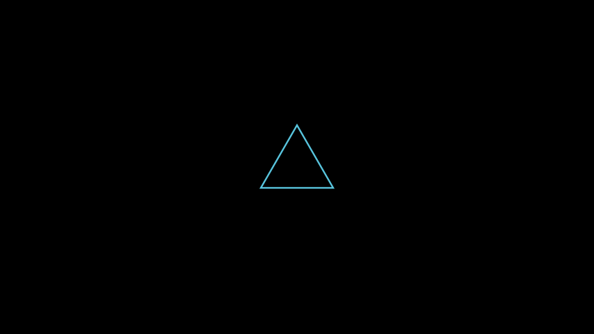

```python
%%manim -ls
class Class1(Scene):
    def construct(self):
        square = Square()
        self.play(ShowCreation(square))
        self.wait(4)
class Class2(Scene):
    def construct(self):
        circle = Circle()
        self.play(ShowCreation(circle))
        self.wait(4)
class Class3(Scene):
    def construct(self):
        triangle = Triangle()
        self.play(ShowCreation(triangle))
        self.wait(4)
```

## *That's all folks :). If you find any issues feel free to open a new Issue on its GitHub's page.*